# Comparing INLA and Stan Implementations in surveyPrev and SUMMER

Zehang Richard Li, Qianyu Dong

This vignette compares the INLA and Stan implementations available through `surveyPrev` and `SUMMER`, and then describes the internal organization of the Stan backend.

# Comparing surveyPrev Model Classes with INLA and Stan

This section compares the main `surveyPrev` model classes using the 2024 Zambia DHS indicator for four or more antenatal care visits. The data are downloaded directly from the DHS website using **rdhs**. This step requires users to

1. register with DHS to gain data access, and
2. set up their DHS account login details with `rdhs::set_rdhs_config()`.

```r
dhs_raw <- getDHSdata(
  country = "Zambia", year = 2024, indicator = "RH_ANCN_W_N4P"
)
anc <- getDHSindicator(dhs_raw, indicator = "RH_ANCN_W_N4P")
gps <- getDHSgeo(country = "Zambia", year = 2024)

data(ZambiaAdm1)
data(ZambiaAdm2)
data(ZambiaPopWomen)
cluster_info <- clusterInfo(gps, ZambiaAdm1, ZambiaAdm2)
admin1_info <- adminInfo(
  ZambiaAdm1, admin = 1, by.adm = "NAME_1",
  agg.pop = ZambiaPopWomen$admin1_pop,
  proportion = ZambiaPopWomen$admin1_urban
)
admin2_info <- adminInfo(
  ZambiaAdm2, admin = 2, by.adm = "NAME_2", by.adm.upper = "NAME_1",
  agg.pop = ZambiaPopWomen$admin2_pop,
  proportion = ZambiaPopWomen$admin2_urban
)
```

Every Stan fit in this vignette uses three chains, 2,000 iterations per chain, and 1,000 warmup iterations per chain. This leaves 1,000 retained draws per chain and 3,000 retained draws in total. The common sampler arguments and comparison plot are defined once below.

```r
stan_args <- list(
  stan.chains = 3,
  stan.iter = 2000,
  stan.warmup = 1000,
  stan.seed = 1,
  stan.cores = 3
)

fit_both <- function(args, model_fun = NULL) {
  if (is.null(model_fun)) {
    return(list(
      INLA = do.call(SUMMER::smoothSurvey, c(args, list(nsim = 1000))),
      Stan = do.call(surveyPrev::smoothSurveyStan, c(args, stan_args))
    ))
  }

  list(
    INLA = do.call(model_fun, c(args, list(engine = "INLA"))),
    Stan = do.call(model_fun, c(args, list(engine = "rstan"), stan_args))
  )
}

model_table <- function(x, table = NULL) {
  if (!is.null(table)) {
    if (is.null(x[[table]])) stop("Model output has no table named '", table, "'.")
    return(x[[table]])
  }
  candidates <- c("res.admin1", "res.admin2", "agg.admin1", "smooth")
  for (name in candidates) if (!is.null(x[[name]])) return(x[[name]])
  stop("No model estimate table found.")
}

comparison_scatter <- function(pair, title, table = NULL) {
  x <- model_table(pair$INLA, table)
  y <- model_table(pair$Stan, table)
  keys <- intersect(
    c("admin1.name", "admin2.name.full", "region", "time", "strata", "type"),
    intersect(names(x), names(y))
  )

  x$.se <- if ("sd" %in% names(x)) x$sd else sqrt(x$var)
  y$.se <- if ("sd" %in% names(y)) y$sd else sqrt(y$var)
  if (length(keys)) {
    x[keys] <- lapply(x[keys], as.character)
    y[keys] <- lapply(y[keys], as.character)
    if (anyDuplicated(x[keys]) || anyDuplicated(y[keys])) {
      stop(
        "The available comparison keys do not uniquely identify model estimates: ",
        paste(keys, collapse = ", "), "."
      )
    }
    x <- x[, c(keys, "mean", ".se")]
    y <- y[, c(keys, "mean", ".se")]
    names(x)[names(x) %in% c("mean", ".se")] <- c("INLA_mean", "INLA_se")
    names(y)[names(y) %in% c("mean", ".se")] <- c("Stan_mean", "Stan_se")
    matched <- merge(x, y, by = keys, all = TRUE, sort = TRUE)
  } else {
    if (nrow(x) != nrow(y)) {
      stop("INLA and Stan outputs have different numbers of estimates.")
    }
    matched <- data.frame(
      INLA_mean = x$mean, INLA_se = x$.se,
      Stan_mean = y$mean, Stan_se = y$.se
    )
  }

  values <- c("INLA_mean", "INLA_se", "Stan_mean", "Stan_se")
  if (anyNA(matched[values])) {
    stop("INLA and Stan outputs do not have the same prediction keys.")
  }
  points <- rbind(
    data.frame(metric = "estimate", INLA = matched$INLA_mean,
               Stan = matched$Stan_mean),
    data.frame(metric = "standard error", INLA = matched$INLA_se,
               Stan = matched$Stan_se)
  )
  axis_bounds <- do.call(rbind, lapply(split(points, points$metric),
    function(z) {
      values <- c(z$INLA, z$Stan)
      values <- values[is.finite(values)]
      limits <- if (length(values)) range(values) else c(0, 1)
      if (diff(limits) == 0) limits <- limits + c(-0.5, 0.5)
      data.frame(metric = z$metric[1], INLA = limits, Stan = limits)
    }
  ))
  ggplot(points, aes(INLA, Stan)) +
    geom_blank(data = axis_bounds) +
    geom_abline(slope = 1, intercept = 0, colour = "grey60",
                linetype = "dashed") +
    geom_point() +
    facet_wrap(~metric, scales = "free") +
    labs(title = title) +
    theme_bw() +
    theme(aspect.ratio = 1)
}
```

## Fay–Herriot Model with an IID Area Effect at Admin 1

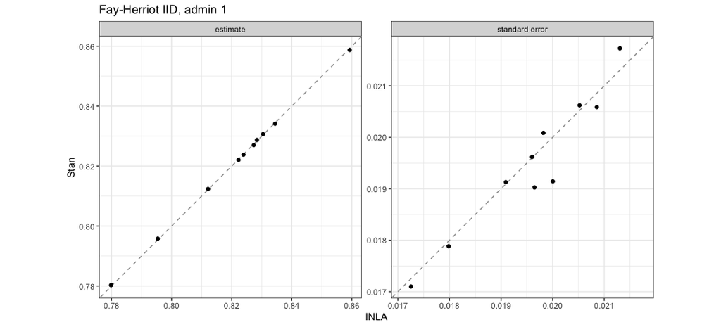

```r
fh_iid <- fit_both(list(
  data = anc, cluster.info = cluster_info, admin.info = admin1_info,
  admin = 1, model = "iid", aggregation = FALSE
), model_fun = fhModel)
comparison_scatter(fh_iid, "Fay-Herriot IID, admin 1")
```

Some computational checks are available using `diagModel()`.

```r
diagModel(fh_iid$INLA)
```

```
#> Model diagnostics (INLA)
#>             check        status                                value
#>  optimizer status          pass                         not reported
#>  latent summaries          pass                               finite
#>   hyperparameters          pass                               finite
#>      CPO failures          pass                                    0
#>   PIT calibration not available not computed or fewer than 20 values
#>                          threshold
#>                                  0
#>  finite means and non-negative SDs
#>                             finite
#>                               <= 0
#>                          p >= 0.01
#>                                                    message
#>                  INLA did not report an optimizer failure.
#>              Fixed and random-effect summaries are finite.
#>                       Hyperparameter summaries are finite.
#>                             No CPO failures were reported.
#>  PIT requires computed CPO values and enough observations.
```

```r
diagModel(fh_iid$Stan)
```

```
#> Model diagnostics (rstan)
#>                  check status                                          value
#>            divergences   pass                                              0
#>      maximum treedepth   pass                                              0
#>                  R-hat   pass                   max 1.003; 0 above threshold
#>  effective sample size   pass             min ratio 0.228; 0 below threshold
#>                 E-BFMI   pass chain 1: 0.804; chain 2: 0.677; chain 3: 0.744
#>  threshold                                   message
#>          0                 No divergent transitions.
#>          0   No transitions saturated max_treedepth.
#>    <= 1.01 All reported R-hat values are acceptable.
#>     >= 0.1      Effective sample sizes are adequate.
#>     >= 0.3         Energy exploration is acceptable.
```

## Fay–Herriot Model with a BYM2 Area Effect at Admin 1

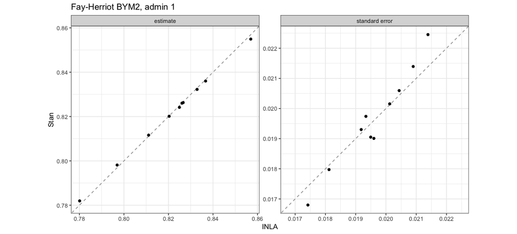

```r
fh_bym2 <- fit_both(list(
  data = anc, cluster.info = cluster_info, admin.info = admin1_info,
  admin = 1, model = "bym2", aggregation = TRUE
), model_fun = fhModel)
comparison_scatter(fh_bym2, "Fay-Herriot BYM2, admin 1")
```

## Fay–Herriot Model with Nested BYM2 Effects at Admin 2

The sparse admin-2 direct estimates require the explicit variance-fix estimator.

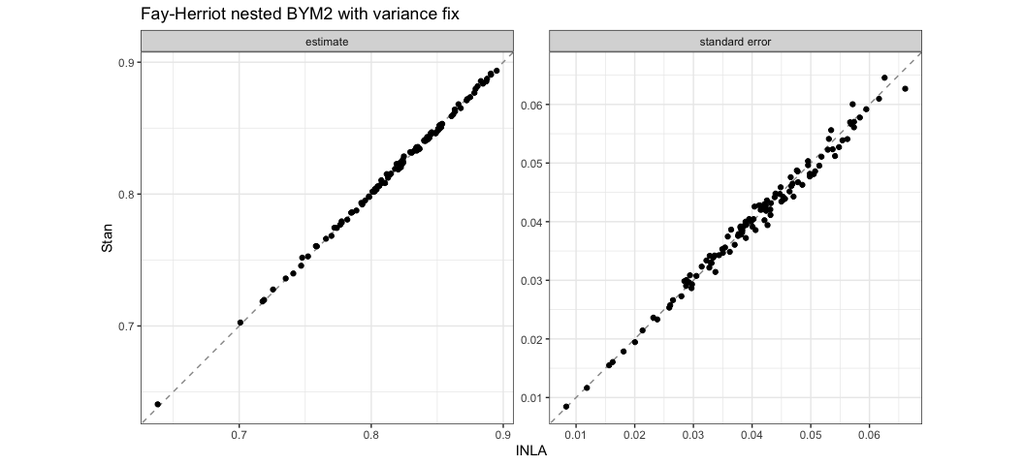

```r
fh_nested <- fit_both(list(
  data = anc, cluster.info = cluster_info, admin.info = admin2_info,
  admin = 2, model = "bym2", nested = TRUE, aggregation = FALSE,
  var.fix = TRUE
), model_fun = fhModel)
comparison_scatter(fh_nested, "Fay-Herriot nested BYM2 with variance fix")
```

## Cluster-Level Model with an IID Area Effect at Admin 1

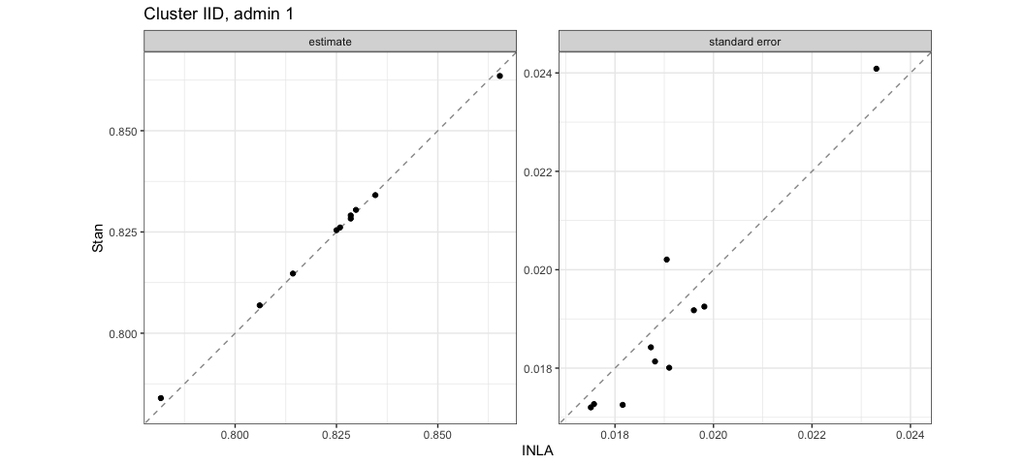

```r
cluster_iid <- fit_both(list(
  data = anc, cluster.info = cluster_info, admin.info = admin1_info,
  admin = 1, model = "iid", aggregation = FALSE
), model_fun = clusterModel)
comparison_scatter(cluster_iid, "Cluster IID, admin 1")
```

## Cluster-Level Model with a BYM2 Area Effect at Admin 1

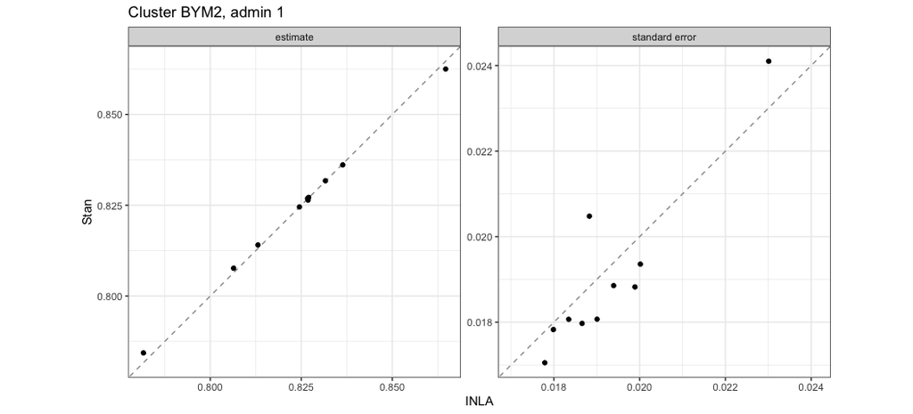

```r
cluster_bym2 <- fit_both(list(
  data = anc, cluster.info = cluster_info, admin.info = admin1_info,
  admin = 1, model = "bym2", aggregation = FALSE
), model_fun = clusterModel)
comparison_scatter(cluster_bym2, "Cluster BYM2, admin 1")
```

## Cluster-Level Model with Stratified BYM2 Effects

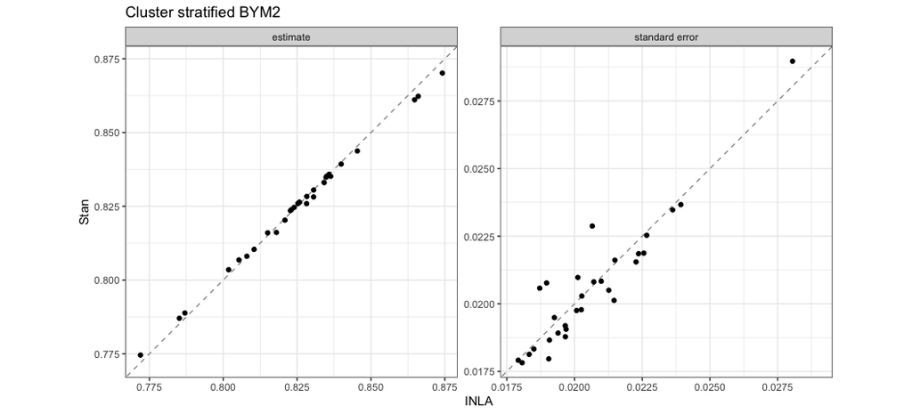

```r
cluster_stratified <- fit_both(list(
  data = anc, cluster.info = cluster_info, admin.info = admin1_info,
  admin = 1, model = "bym2", stratification = TRUE,
  aggregation = TRUE
), model_fun = clusterModel)
comparison_scatter(cluster_stratified, "Cluster stratified BYM2")
```

## Cluster-Level Model with Nested BYM2 Effects at Admin 2

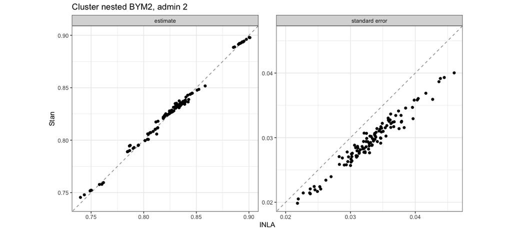

```r
cluster_nested <- fit_both(list(
  data = anc, cluster.info = cluster_info, admin.info = admin2_info,
  admin = 2, model = "bym2", nested = TRUE, aggregation = FALSE
), model_fun = clusterModel)
comparison_scatter(cluster_nested, "Cluster nested BYM2, admin 2")
```

# Comparing Models from SUMMER::smoothSurvey with INLA and Stan

This section compares the INLA implementation in `SUMMER::smoothSurvey()` with the Stan implementation in `surveyPrev::smoothSurveyStan()`.

The `smoothSurvey` examples use the same sampler settings, `fit_both()` helper, and `comparison_scatter()` function defined above. All 3,000 retained Stan draws are used in SUMMER’s post-processing; if supplied, `nsim` is overwritten by this retained draw count for the Stan fit.

We will go through major use cases for the `smoothSurvey` function using the examples with the demo datasets.

```r
data(DemoData2, package = "SUMMER")
data(DemoMap2, package = "SUMMER")
Xmat <- aggregate(age ~ region, DemoData2, mean)
base_binary <- list(
  data = DemoData2, Amat = DemoMap2$Amat, response.type = "binary",
  responseVar = "tobacco.use", strataVar = "strata",
  weightVar = "weights", regionVar = "region",
  clusterVar = "~clustid+id", CI = 0.95
)
```

## Area-level FH model with binary outcome, BYM2 prior

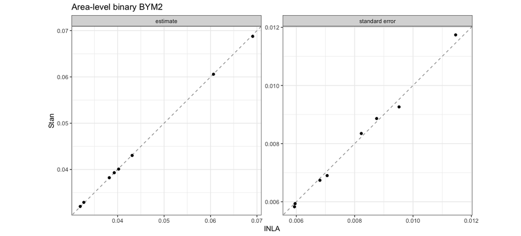

```r
area_binary <- fit_both(base_binary)
comparison_scatter(area_binary, "Area-level binary BYM2")
```

## Area-level FH model with binary outcome, SAR prior

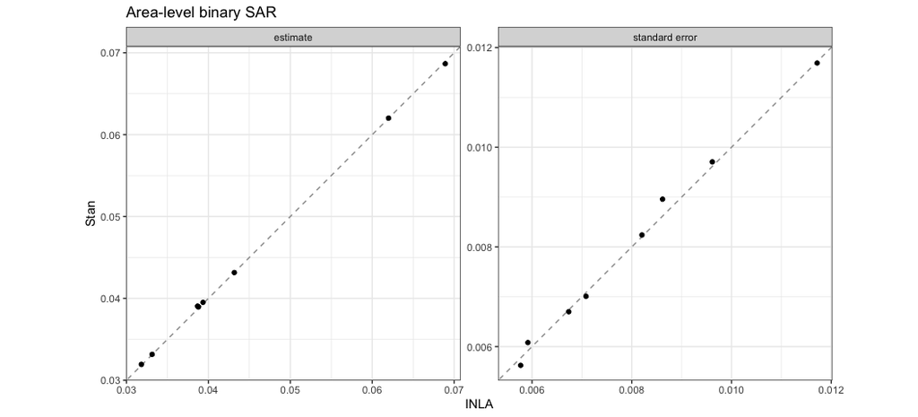

```r
area_sar <- fit_both(c(base_binary, list(space.model = "sar")))
comparison_scatter(area_sar, "Area-level binary SAR")
```

## Area-level FH model with binary outcome, unmatched link function

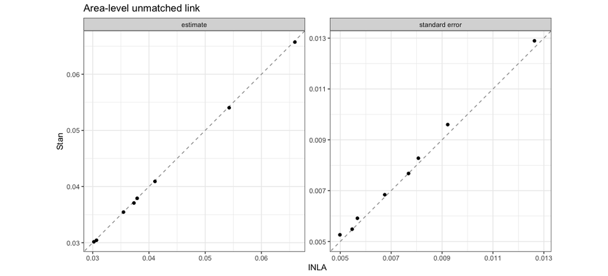

```r
area_unmatched <- fit_both(c(base_binary, list(unmatched.link = TRUE)))
comparison_scatter(area_unmatched, "Area-level unmatched link")
```

## Area-level FH model with covariate

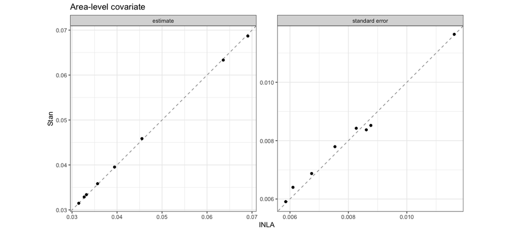

```r
area_covariate <- fit_both(c(base_binary, list(X = Xmat)))
comparison_scatter(area_covariate, "Area-level covariate")
```

## Area-level FH model with direct estimates of prevalence

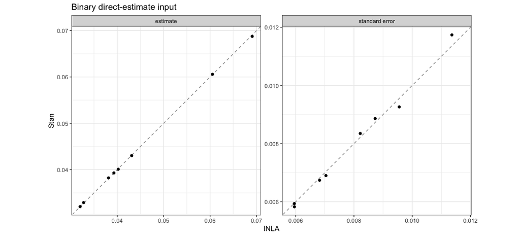

```r
direct_binary <- area_binary$INLA$direct[, c("region", "direct.est", "direct.var")]
direct_binary_fit <- fit_both(list(
  data = NULL, direct.est = direct_binary, Amat = DemoMap2$Amat,
  regionVar = "region", responseVar = "direct.est",
  direct.est.var = "direct.var", response.type = "binary"
))
comparison_scatter(direct_binary_fit, "Binary direct-estimate input")
```

## Area-level FH model with direct estimates of a Gaussian outcome

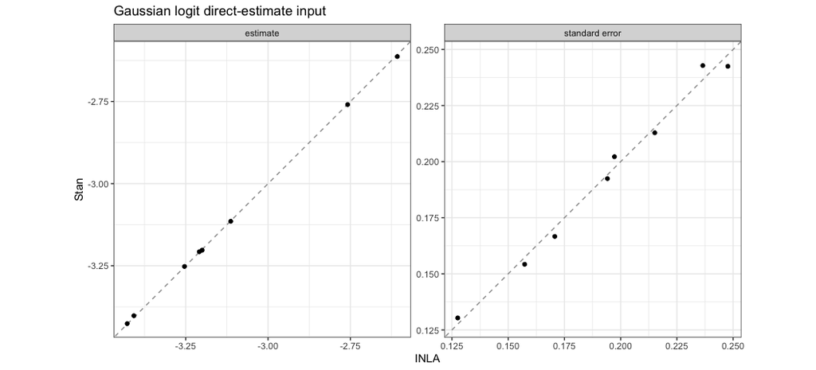

```r
direct_logit <- area_binary$INLA$direct[
  , c("region", "direct.logit.est", "direct.logit.var")
]
direct_logit_fit <- fit_both(list(
  data = NULL, direct.est = direct_logit, Amat = DemoMap2$Amat,
  regionVar = "region", responseVar = "direct.logit.est",
  direct.est.var = "direct.logit.var", response.type = "gaussian"
))
comparison_scatter(direct_logit_fit, "Gaussian logit direct-estimate input")
```

## Unit-level model with binary outcome

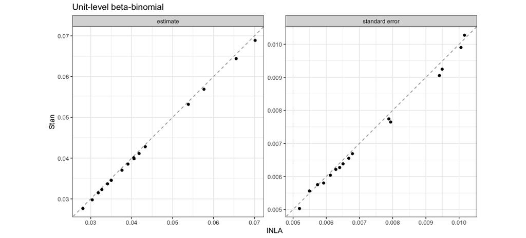

```r
unit_data <- DemoData2
unit_data$urbanicity <- ifelse(grepl("urban", unit_data$strata),
                               "urban", "rural")
unit_binary <- fit_both(list(
  data = unit_data, Amat = DemoMap2$Amat, response.type = "binary",
  X = Xmat, is.unit.level = TRUE, responseVar = "tobacco.use",
  strataVar.within = "urbanicity", regionVar = "region",
  clusterVar = "clustid", CI = 0.95
))
comparison_scatter(unit_binary, "Unit-level beta-binomial")
```

## Unit-level model with aggregated cluster counts

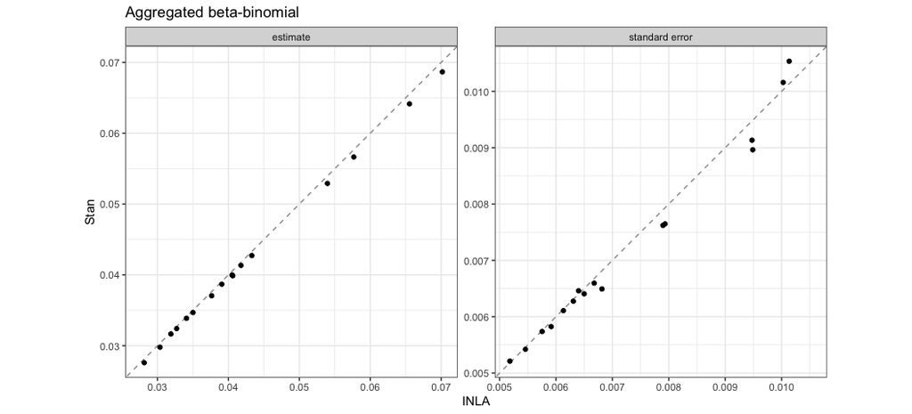

```r
counts <- aggregate(tobacco.use ~ region + urbanicity + clustid,
                    unit_data, sum)
totals <- aggregate(tobacco.use ~ region + urbanicity + clustid,
                    unit_data, length)
names(totals)[4] <- "total"
counts <- merge(counts, totals)
unit_counts <- fit_both(list(
  data = counts, Amat = DemoMap2$Amat, response.type = "binary",
  X = Xmat, is.unit.level = TRUE, is.agg = TRUE,
  responseVar = "tobacco.use", strataVar.within = "urbanicity",
  totalVar = "total", regionVar = "region", clusterVar = "clustid"
))
comparison_scatter(unit_counts, "Aggregated beta-binomial")
```

## Area-level model with Gaussian outcome

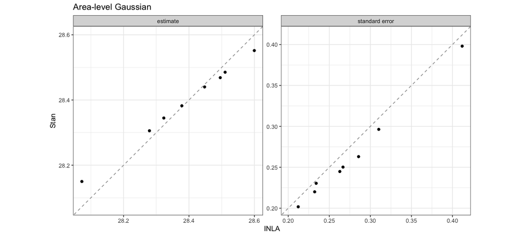

```r
area_gaussian <- fit_both(list(
  data = DemoData2, Amat = DemoMap2$Amat, response.type = "gaussian",
  responseVar = "age", strataVar = "strata", weightVar = "weights",
  regionVar = "region", clusterVar = "~clustid+id"
))
comparison_scatter(area_gaussian, "Area-level Gaussian")
```

## Unit-level nested-error model

The sample response and satellite covariates are from 12 Iowa counties. The county-level covariate means are supplied in `X` for prediction.

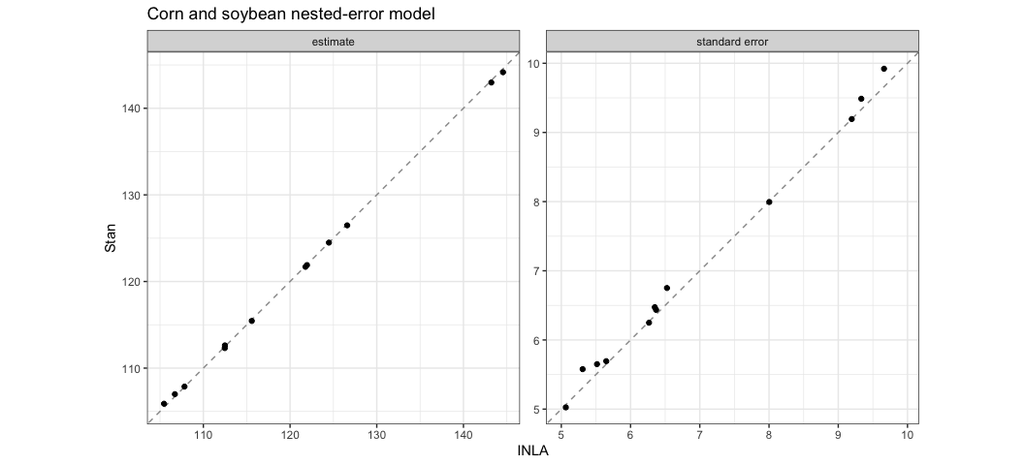

```r
data(cornsoybean, package = "sae")
data(cornsoybeanmeans, package = "sae")
cornsoybean <- cornsoybean[-33, , drop = FALSE] # remove outlier
cornsoybean_X <- data.frame(cornsoybeanmeans[
  , c("CountyIndex", "MeanCornPixPerSeg", "MeanSoyBeansPixPerSeg")
])
names(cornsoybean_X) <- c("County", "CornPix", "SoyBeansPix")

cornsoybean_pair <- fit_both(list(
  data = cornsoybean, X.unit = c("CornPix", "SoyBeansPix"),
  X = cornsoybean_X, Amat = NULL,
  response.type = "gaussian", is.unit.level = TRUE,
  responseVar = "CornHec", regionVar = "County", clusterVar = NULL,
  pc.u = 1000, pc.alpha = 0.01, CI = 0.95
))
comparison_scatter(cornsoybean_pair,
                   "Corn and soybean nested-error model")
```

## Neonatal mortality with RW2 and Type I–IV interactions

```r
data(DemoData, package = "SUMMER")
data(DemoMap, package = "SUMMER")
nmr_births <- lapply(DemoData, function(x) {
  x[as.character(x$age) == "0", , drop = FALSE]
})
names(nmr_births) <- names(DemoData)
periods <- levels(DemoData[[1]]$time)
nmr_multi <- SUMMER::getDirectList(
  births = nmr_births, years = periods, regionVar = "region",
  timeVar = "time", clusterVar = "~clustid+id", ageVar = "age",
  weightsVar = "weights"
)
nmr_direct <- SUMMER::aggregateSurvey(nmr_multi)
nmr_direct <- subset(nmr_direct, region != "All")
nmr_direct$time_index <- match(nmr_direct$years, periods)
nmr_direct$variance <- nmr_direct$var.est *
  (nmr_direct$mean * (1 - nmr_direct$mean))^2
```

```r
nmr_type_labels <- paste("Type", c("I", "II", "III", "IV"))
nmr_pairs <- setNames(vector("list", 4), nmr_type_labels)
for (interaction in 1:4) {
  label <- nmr_type_labels[interaction]
  nmr_pairs[[label]] <- fit_both(list(
    data = NULL, direct.est = nmr_direct, Amat = DemoMap$Amat,
    regionVar = "region", timeVar = "time_index",
    responseVar = "mean", direct.est.var = "variance",
    response.type = "binary", time.model = "rw2",
    type.st = interaction
  ))
}
```

We compare the estimates and standard errors for all four fits below.

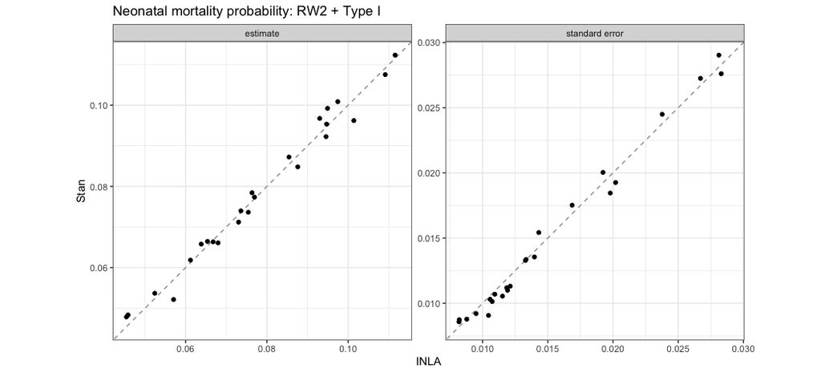

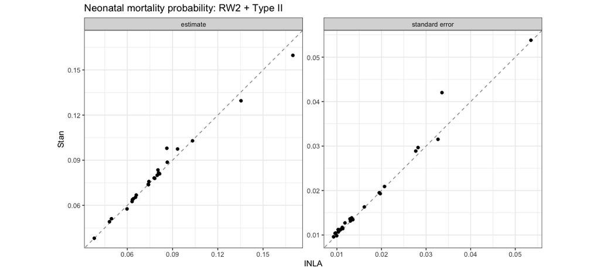

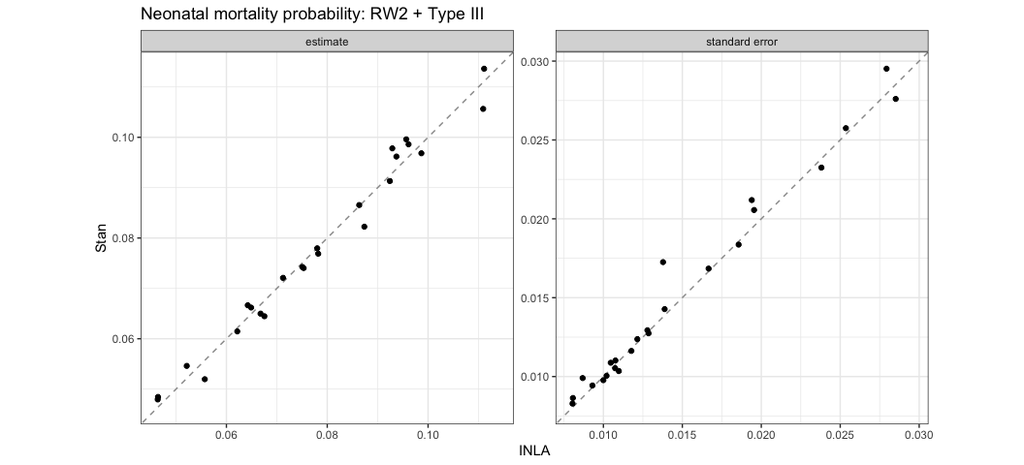

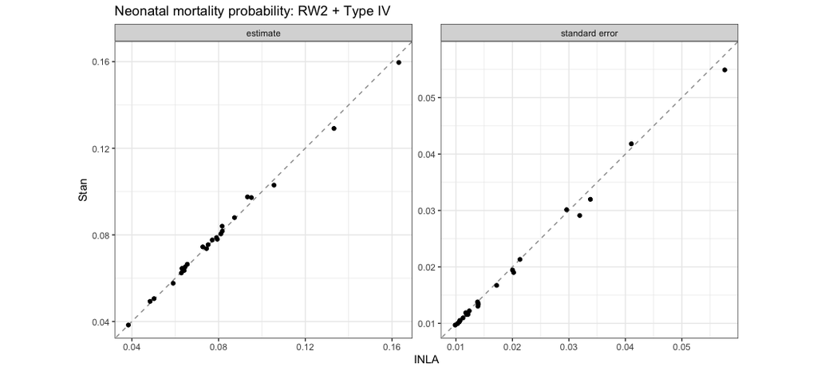

```r
for (label in nmr_type_labels) {
  print(comparison_scatter(
    nmr_pairs[[label]],
    paste("Neonatal mortality probability: RW2 +", label)
  ))
}
```

For the four NMR models, we also compare posterior means and 95% credible intervals for the intercept, variance and mixing parameters, main spatial and temporal effects, and every region-by-period interaction. INLA precision parameters are transformed to standard deviations so that they have the same interpretation as the corresponding Stan parameters. The BYM2 spatial effect shown below is the combined structured and unstructured effect used in the linear predictor. Thus, every latent random effect entering the predictor is compared on the model’s logit scale. Each point is a posterior mean, each line is a central 95% credible interval, and color identifies INLA or rstan. Within each panel, the x-axis groups the four interaction types so that each type has one INLA–rstan pair.

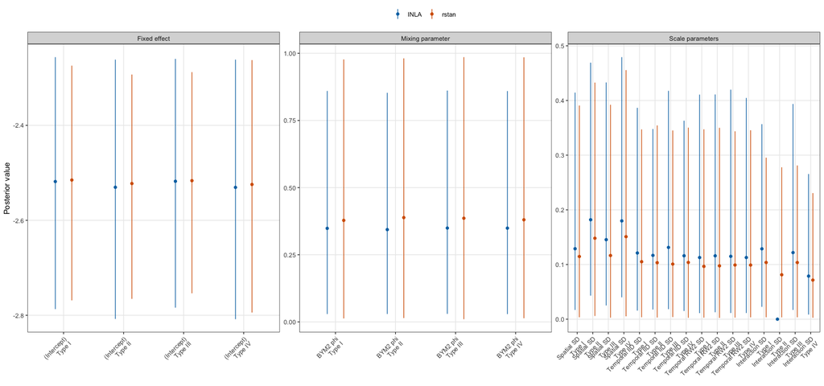

```r
nmr_fits <- lapply(nmr_pairs, function(pair) {
  list(
    inla = pair$INLA$fit,
    stan = pair$Stan$fit$stanfit,
    draws = rstan::extract(pair$Stan$fit$stanfit, permuted = TRUE)
  )
})
nmr_regions <- colnames(DemoMap$Amat)
nmr_times <- sort(unique(nmr_direct$time_index))
nmr_time_labels <- periods[nmr_times]

inla_interval <- function(marginal, transform = identity) {
  clean_marginal <- function(x) {
    x <- as.matrix(x)
    x <- x[is.finite(x[, 1]) & is.finite(x[, 2]), , drop = FALSE]
    x <- x[order(x[, 1]), , drop = FALSE]
    if (anyDuplicated(x[, 1])) {
      x <- stats::aggregate(x[, 2], list(x[, 1]), mean)
    }
    if (nrow(x) < 2L) stop("The INLA marginal has too few finite points.")
    as.matrix(x)
  }
  marginal <- clean_marginal(marginal)
  marginal <- INLA::inla.tmarginal(transform, marginal)
  marginal <- clean_marginal(marginal)
  c(
    mean = unname(INLA::inla.emarginal(identity, marginal)),
    lower = unname(INLA::inla.qmarginal(0.025, marginal)),
    upper = unname(INLA::inla.qmarginal(0.975, marginal))
  )
}

stan_intervals <- function(draws, parameter, component, interaction_type) {
  if (length(dim(draws)) < 2L) draws <- matrix(draws, ncol = 1)
  if (ncol(draws) != length(parameter)) {
    stop("The number of rstan parameters does not match its labels.")
  }
  intervals <- t(apply(draws, 2, function(x) {
    c(mean = mean(x), quantile(x, c(0.025, 0.975), names = FALSE))
  }))
  data.frame(
    component = component, parameter = parameter,
    mean = intervals[, 1], lower = intervals[, 2], upper = intervals[, 3],
    method = "rstan", interaction_type = interaction_type, row.names = NULL
  )
}

inla_random_intervals <- function(fit, name, n, parameter, component,
                                  interaction_type, index = seq_len(n)) {
  x <- fit$summary.random[[name]]
  if (is.null(x) || nrow(x) < n || length(parameter) != n ||
      length(index) != n || any(index < 1L | index > nrow(x))) {
    stop("The INLA random-effect dimensions do not match their labels.")
  }
  x <- x[index, ]
  data.frame(
    component = component, parameter = parameter,
    mean = x$mean, lower = x$`0.025quant`, upper = x$`0.975quant`,
    method = "INLA", interaction_type = interaction_type, row.names = NULL
  )
}

inla_hyper_intervals <- function(fit, name, parameter, interaction_type,
                                 transform = identity,
                                 component = "Scale parameters") {
  marginal <- fit$internal.marginals.hyperpar[[name]]
  if (is.null(marginal)) {
    stop("The INLA hyperparameter marginal was not found: ", name)
  }
  z <- inla_interval(marginal, transform)
  data.frame(
    component = component, parameter = parameter,
    mean = z["mean"], lower = z["lower"], upper = z["upper"],
    method = "INLA", interaction_type = interaction_type, row.names = NULL
  )
}

comparison_axis <- function(data, parameter_levels) {
  data$interaction_type <- factor(data$interaction_type, nmr_type_labels)
  axis_levels <- as.vector(t(outer(
    parameter_levels, nmr_type_labels, paste, sep = "\n"
  )))
  data$parameter_type <- factor(
    paste(data$parameter, data$interaction_type, sep = "\n"), axis_levels
  )
  data
}

interval_plot <- function(data, x) {
  dodge <- position_dodge(width = 0.55)
  ggplot(data, aes(x = {{ x }}, y = mean, colour = method, group = method)) +
    geom_linerange(aes(ymin = lower, ymax = upper),
                   position = dodge, linewidth = 0.45) +
    geom_point(position = dodge, size = 1.5) +
    scale_colour_manual(values = c(INLA = "#0072B2", rstan = "#D55E00")) +
    labs(x = NULL, y = "Posterior value", colour = NULL) +
    theme_bw() +
    theme(
      legend.position = "top", panel.grid.minor = element_blank(),
      axis.text.x = element_text(angle = 45, hjust = 1)
    )
}

nmr_global <- do.call(rbind, lapply(nmr_type_labels, function(type) {
  inla_fit <- nmr_fits[[type]]$inla
  draws <- nmr_fits[[type]]$draws
  inla_fixed <- inla_fit$summary.fixed
  interaction_name <- if (type %in% c("Type II", "Type IV")) {
    "time.area"
  } else {
    "region.int"
  }
  rbind(
    data.frame(
      component = "Fixed effect", parameter = rownames(inla_fixed),
      mean = inla_fixed$mean, lower = inla_fixed$`0.025quant`,
      upper = inla_fixed$`0.975quant`, method = "INLA",
      interaction_type = type, row.names = NULL
    ),
    stan_intervals(
      draws$beta, rownames(inla_fixed), "Fixed effect", type
    ),
    inla_hyper_intervals(
      inla_fit, "Log precision for region.struct", "Spatial SD", type,
      function(x) exp(-x / 2)
    ),
    inla_hyper_intervals(
      inla_fit, "Logit phi for region.struct", "BYM2 phi", type, plogis,
      component = "Mixing parameter"
    ),
    inla_hyper_intervals(
      inla_fit, "Log precision for time.unstruct", "Temporal IID SD", type,
      function(x) exp(-x / 2)
    ),
    inla_hyper_intervals(
      inla_fit, "Log precision for time.struct", "Temporal RW2 SD", type,
      function(x) exp(-x / 2)
    ),
    inla_hyper_intervals(
      inla_fit, paste("Log precision for", interaction_name),
      "Interaction SD", type,
      function(x) exp(-x / 2)
    ),
    stan_intervals(
      draws$sigma_space, "Spatial SD", "Scale parameters", type
    ),
    stan_intervals(draws$phi, "BYM2 phi", "Mixing parameter", type),
    stan_intervals(
      draws$sigma_time_unstruct, "Temporal IID SD", "Scale parameters", type
    ),
    stan_intervals(
      draws$sigma_time_struct, "Temporal RW2 SD", "Scale parameters", type
    ),
    stan_intervals(
      draws$sigma_st, "Interaction SD", "Scale parameters", type
    )
  )
}))
nmr_global$method <- factor(nmr_global$method, c("INLA", "rstan"))
nmr_global <- comparison_axis(
  nmr_global,
  c("(Intercept)", "Spatial SD", "BYM2 phi", "Temporal IID SD",
    "Temporal RW2 SD", "Interaction SD")
)

interval_plot(nmr_global, parameter_type) +
  facet_wrap(~component, scales = "free")
```

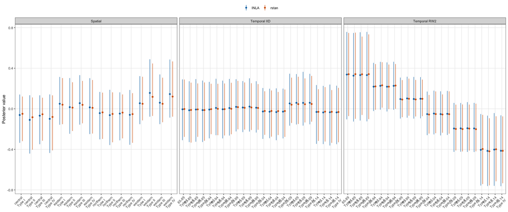

```r
nmr_main_random <- do.call(rbind, lapply(nmr_type_labels, function(type) {
  inla_fit <- nmr_fits[[type]]$inla
  draws <- nmr_fits[[type]]$draws
  rbind(
    inla_random_intervals(
      inla_fit, "region.struct", length(nmr_regions), nmr_regions,
      "Spatial", type
    ),
    stan_intervals(draws$re_space, nmr_regions, "Spatial", type),
    inla_random_intervals(
      inla_fit, "time.unstruct", length(nmr_times), nmr_time_labels,
      "Temporal IID", type
    ),
    stan_intervals(
      draws$re_time_unstruct, nmr_time_labels, "Temporal IID", type
    ),
    inla_random_intervals(
      inla_fit, "time.struct", length(nmr_times), nmr_time_labels,
      "Temporal RW2", type
    ),
    stan_intervals(
      draws$re_time_struct, nmr_time_labels, "Temporal RW2", type
    )
  )
}))
nmr_main_random$method <- factor(nmr_main_random$method, c("INLA", "rstan"))
nmr_main_random <- comparison_axis(
  nmr_main_random, c(nmr_regions, nmr_time_labels)
)

interval_plot(nmr_main_random, parameter_type) +
  facet_wrap(~component, nrow = 1, scales = "free_x")
```

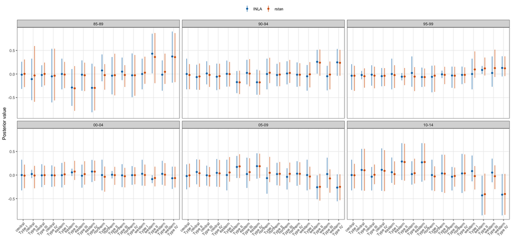

```r
nmr_interaction_index <- expand.grid(
  region = nmr_regions, time = nmr_time_labels,
  KEEP.OUT.ATTRS = FALSE, stringsAsFactors = FALSE
)
nmr_interaction <- do.call(rbind, lapply(nmr_type_labels, function(type) {
  inla_name <- if (type %in% c("Type II", "Type IV")) {
    "time.area"
  } else {
    "region.int"
  }
  # INLA's Type II/IV generic0 fields are region-major; the other fields and
  # Stan are time-major, matching nmr_interaction_index.
  inla_index <- if (type %in% c("Type II", "Type IV")) {
    (match(nmr_interaction_index$region, nmr_regions) - 1L) *
      length(nmr_time_labels) +
      match(nmr_interaction_index$time, nmr_time_labels)
  } else {
    seq_len(nrow(nmr_interaction_index))
  }
  block <- rbind(
    inla_random_intervals(
      nmr_fits[[type]]$inla, inla_name, nrow(nmr_interaction_index),
      nmr_interaction_index$region, "Space-time interaction", type,
      index = inla_index
    ),
    stan_intervals(
      nmr_fits[[type]]$draws$re_st, nmr_interaction_index$region,
      "Space-time interaction", type
    )
  )
  block$time <- rep(nmr_interaction_index$time, times = 2)
  block
}))
nmr_interaction$method <- factor(nmr_interaction$method, c("INLA", "rstan"))
nmr_interaction$time <- factor(nmr_interaction$time, nmr_time_labels)
nmr_interaction <- comparison_axis(nmr_interaction, nmr_regions)

interval_plot(nmr_interaction, parameter_type) +
  facet_wrap(~time, nrow = 2)
```

# Understanding the Internal Design of the Stan Backend

The call path is

```
smoothSurveyStan()
  -> SUMMER::smoothSurvey(.backend = ...)
       -> .stan_smoothSurvey_fit()
            -> fh_gaussian.stan or betabinom.stan
            -> posterior draws in the form expected by SUMMER
```

`SUMMER::smoothSurvey()` continues to perform the common survey-data preparation and assemble the returned estimates. The functions in `surveyPrev` translate that prepared model input to Stan and translate the draws back to the small posterior interface used by SUMMER.

## Interface, Data Preparation, and Supporting Infrastructure

[output not shown]

The `.backend` argument in `SUMMER::smoothSurvey()` is the boundary between the two packages. Changes to survey design processing, direct-estimate construction, or final aggregation normally belong in SUMMER. Changes to Stan data construction, sampling, or draw extraction belong in `.stan_smoothSurvey_fit()`.

## Model-Specific Preparation and Prior Specification

[output not shown]

The general PC scale-prior rate is computed in R as `lambda = -log(pc.alpha) / pc.u`. Fixed-effect precisions, beta-binomial overdispersion hyperparameters, graph scaling constants, and BYM2 `phi` prior inputs are also created in R. Their actual contribution to the posterior is defined in the Stan `model` blocks.

## Stan Model Specification

| Program or block | Responsibility |
| --- | --- |
| `inst/stan/fh_gaussian.stan` | Gaussian Fay–Herriot likelihoods with known sampling variance, unmatched-link models, and unit-level Gaussian models with estimated residual precision. |
| `inst/stan/betabinom.stan` | Beta-binomial likelihood and overdispersion model used for unit-level binary `smoothSurveyStan()` fits and `clusterModel()` fits. |
| `interpolate_lpdf()` in the `functions` block | Linearly interpolates the tabulated INLA BYM2 log-density supplied by R. |
| `pc_bym2_phi_lpdf()` in the `functions` block | Evaluates the alternative analytic spectral BYM2 `phi` density. |
| `data` | Declares the interface produced by `.stan_smoothSurvey_fit()` or `stan_betabinomial()`. Any declaration change must be matched in the corresponding R data list. |
| `parameters` | Declares fixed effects, scale and mixing parameters, unscaled spatial, temporal, and interaction effects, and the unpenalized RW2 slope directions retained by `smoothDirect()`. |
| `transformed parameters` | Constructs the BYM2, SAR, temporal, and Type I–IV effects that enter the linear predictor, including their scaling and separate RW2 linear trends. |
| `model` | Defines fixed-effect and PC priors, BYM2/Besag penalties, constraints, RW1/RW2 penalties, Type I–IV interaction structures, and the observation likelihood. |
| `generated quantities` | Returns linear predictors and, for the beta-binomial model, predicted probabilities consumed by the R adapters. |

The two Stan programs intentionally use the same spatial, temporal, interaction, constraint, and BYM2-prior formulation. A revision to any of those shared model components should therefore be made in both programs and tested for both likelihoods.

## Where to Modify the Stan Backend

| Intended revision | Start here | Also check |
| --- | --- | --- |
| Change a likelihood or add an observation-level parameter | The relevant file in `inst/stan` | The Stan data and extraction code in `.stan_smoothSurvey_fit()`; for cluster models, `stan_betabinomial()` |
| Change a prior already implemented in Stan | The `model` block in both Stan programs | The R construction of its hyperparameters in `.stan_smoothSurvey_fit()` or `.prepare_bym2_graph_stan()` |
| Change the BYM2 `phi` prior | `.prepare_bym2_graph_stan()` and the Stan `functions`/`model` blocks | Both Stan programs and graph-prior tests |
| Change disconnected-graph or ICAR scaling behavior | `.validate_adjacency_stan()`, `.graph_components_stan()`, and `.prepare_bym2_graph_stan()` | BYM2 and Type III/IV code in both Stan programs |
| Change RW1, RW2, or Type I–IV interactions | `transformed parameters` and `model` in both Stan programs | `.rw_scaling_factor_stan()`, model codes in `.stan_smoothSurvey_fit()`, and linear-predictor indexing |
| Change identifiability constraints | The `constr` sections of both Stan `model` blocks | Graph-component metadata and `constr` propagation from `smoothSurveyStan()` |
| Add a public model or sampler argument | `smoothSurveyStan()` | `.stan_smoothSurvey_backend()`, `.stan_smoothSurvey_fit()`, and documentation |
| Change returned latent effects or predictions | Generated quantities in Stan and extraction in `.stan_smoothSurvey_fit()` | The backend callbacks and SUMMER’s expected latent names |
| Change diagnostic thresholds or checks | `diagModel()` or `.diag_stan()` | Tests in `tests/testthat/test-diagModel.R` |

After changing either Stan program, first run `rstan::stanc()` on the modified file to check its syntax. Then test the affected likelihood, spatial model, temporal model, and interaction type; changes to shared random-effect code should be tested against both Stan programs.